# Report: act_report

From the data which was gathered, assessed and cleaned by me, i was able to produce useful insights using some of the qualities showing relationships. Some of the insights are as follows:

#### What dog_breed is the most popular among tweets?

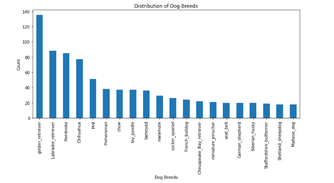

#### Find the tweets with the most and least favorites counts?

The tweet withthe most retweets from my dataset was of a dog standing in a pool and the tweet quoted "**Here's a doggo realizing you can stand in a pool. 13/10 enlightened af (vid by Tina Conrad)**".

The tweet with the least favorites and retweet counts are the same with the tweet content being "**Oh my. Here you are seeing an Adobe Setter giving birth to twins!!! The world is an amazing place. 11/10**". The image below is a visual representation of the tweet.

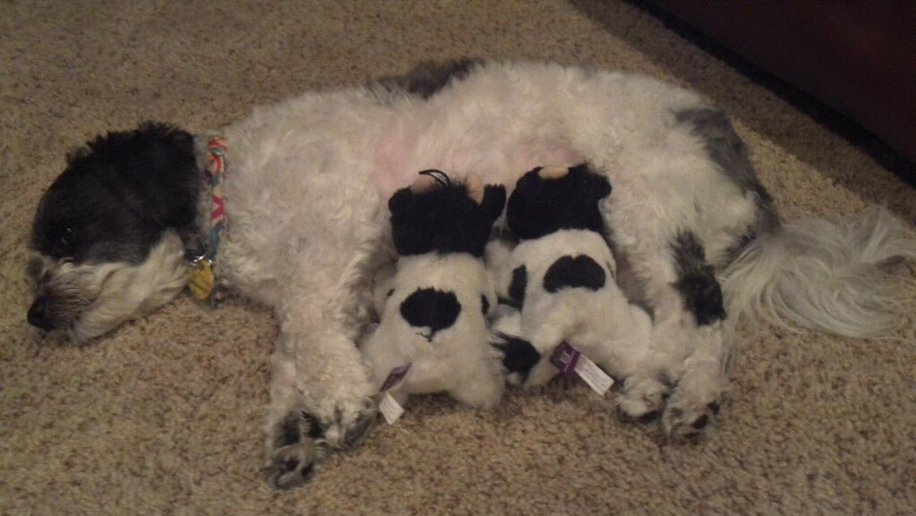

#### What time of the day is the account most active?

For my next analysis, i queried the dataset to find out what time of day traffic is usually at its peak for the we rate dogs account. In doing that, I used the pd.cut function to assign the timestamp into bins and created a new column to contain the results. After plotting the chart, it was observed that the time of day when the account posts the most tweets overtime is the twilight period(the hours between 12:00am and 6:00am).

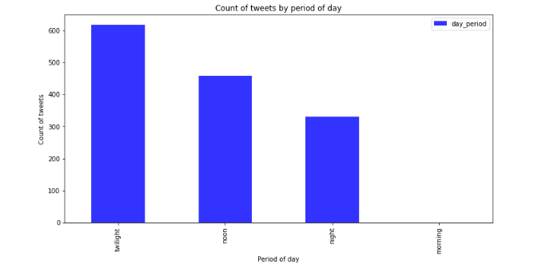

#### What is the relationship between the retweet count and favorite count?

This was my 4th and final insight for this project. I plotted this graph using a scatter plot and the result below was generated.

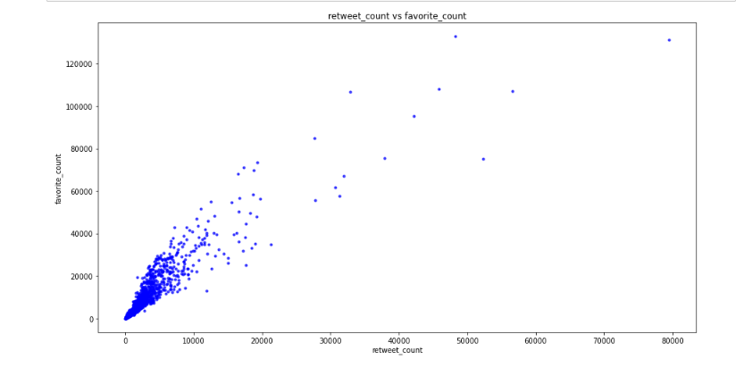

From the chart above, the favorite counts and the retweet counts are simultaneous in nature i.e. as the count of retweets increase, the count of favorites also increase and vice versa.